# Analyzing MeRIP-seq data with PoissonGamma

Zijie Zhang, Allen Zhu, Chuan He, Mengjie Chen

8 March 2018

Abstract

A basic task in the analysis of MeRIP-seq is the detection of differentially methylated loci on the RNA. To analyze the count data of MeRIP-seq, we divide the transcript (concatenated exons of a gene) into consecutive bins and quantify the reads align to each bin. The summarized count data is in table format where each row represent a loci and each column is an sample. Statistical inference of changes across group, as compared to within-group variability was made for each bin with sufficient count. This vignette explains the use of the package RADAR with example data. RADAR package version: 0.1.2

Other Bioconductor packages with similar aims are exomePeak, MeTDiff [QNB](https://cran.r-project.org/web/packages/QNB/index.html).

## 1.Quick start

Here we show the most basic steps for a differential methylation analysis. There are one major steps upstream of radar that generate mapped reads in BAM files for each sample, which can be done by varies choices of softwares such as [Hisat2](https://ccb.jhu.edu/software/hisat2/index.shtml), [tophat2](http://www.ccb.jhu.edu/software/tophat/index.shtml) or [Kallisto](https://pachterlab.github.io/kallisto/). we will discuss in the sections below assuming BAM file has been obtained.

This code chunk assumes that you have bam files for sample1-6 `s1.input.bam... s6..input.bam` and `s1.m6A.bam... s6..m6A.bam` and a vector of group asignment `X = c("Ctl","Ctl","Ctl","Treated","Treated","Treated")`.

```r
radar <- countReads(
  samplenames = c("s1","s2","s3","s4","s5","s6"),
  gtf = "/path/to/file.gtf",
  bamFolder = "/path/to/bam files",
  modification = "m6A",
  strandToKeep = "opposite"
)

radar <- normalizeLibrary( radar, X )
radar <- adjustExprLevel( radar )
radar <- filterBins( radar ,minCountsCutOff = 15)
radar <- diffIP(radar)
res <- reportPoissonGammaMerge(radar,cutoff = 0.1)
```

## 2.How to get help for

Issues and questions about the package should be posted to the [issue report page of the github](https://github.com/scottzijiezhang/RADAR/issues). The issue discussed here can served as public knowledge base.

## 3.Standard workflow

### a). Mapped BAM file.

To analyze for MeRIP-seq data, **RADAR** expect a pair of BAM file for each sample. For each pair of BAM file, the naming convention for **RADAR** is `sample.input.bam` for **INPUT** and `sample.m6A.bam` for m6A **IP** or `sample.m1A.bam` for m1A **IP** sample. They key is **INPUT** and **IP** sample have the same prefix.

### b). GTF annotation file.

For the organism being analyzed, user need to provide an annotation file in gtf format to define the genomic coordinate of gene features. A good source to download those supporting files are [iGenome](https://support.illumina.com/sequencing/sequencing_software/igenome.html).

### c). The RADAR DataSet

The **List** object used by the RADAR package to store the read counts and associated parameters, which will usually be represented in the code here as an object `radar`.

We will use a toy data set to demonstrate how to start from bam file to count reads in consecutive bins and construct a RADAR dataset. There are 9 contols and 8 cases sample in the toy dataset. We name them by Ctl# and Case# in the follow demonstrations.  
Please note that user should set `bam_dir` to directory where bam files are saved instead of setting it to package assocated example file folder `system.file("extdata",package = "RADAR")`.

```r
library(RADAR)
samplenames <- c( paste0("Ctl",1:9), paste0("Case",1:8) )
bam_dir <- "~/PoissonGamma_Method/data"
samplenames
```

```
##  [1] "Ctl1"  "Ctl2"  "Ctl3"  "Ctl4"  "Ctl5"  "Ctl6"  "Ctl7"  "Ctl8"
##  [9] "Ctl9"  "Case1" "Case2" "Case3" "Case4" "Case5" "Case6" "Case7"
## [17] "Case8"
```

Here we created a character vector `samplenames` to define the names of sample, which will later tells RADAR to look for **input** and **IP** file with prefix samplenames.  
Next we need to use `countReads()` function to 1) concatenate exons of each gene to get a “longest isoform” transcript of each gene. 2) Divide transcripts into consecutive bins of user defined width. 3) count reads mapped to each bin.  
**note1** The parameter `modification = "m6A"` tells the function to look for bam file of IP by the name `samplename.m6A.bam`. If the user named the IP sample as `samplename.IP.bam`, `modification` should be set to `modification = "IP`. We enable flexible seeting for IP sample in cases where user perform MeRIP seq on multiple modification with shared **INPUT** library.  
**note2** In Linux or MacOs, our package support multi-thread mode enabled by R package [doParallel](https://cran.r-project.org/web/packages/doParallel/index.html) . One can set the number of threads to use by `threads = n`.  
**note3** The default setting for bin width to slice the transcript is 50bp. One can set this by parameter `binSize = #bp`. For very shallow sequencing depth (e.g. less than 10M mappable reads per library), we recommand setting bin width to larger size such as 100bp to increase the number of reads countable in each bin.  
**note4** The parameter `shift` defines the number of nucleotide to shift from 5’ end of reads to the center of RNA fragment. This number should be set to the half of your RNA fragment size in the sequencing library. In the example data, the RNA has been sonicated into ~150nt fragment before IP and library preparation.

```r
radar <- countReads(samplenames = samplenames,
                    gtf = "~/Database/genome/hg38/hg38_UCSC.gtf",
                    bamFolder = bam_dir,
                    modification = "m6A",
                    shift = 75,
                    outputDir = "test",
                    threads = 12,
                    binSize = 50
)
```

```
## Reading gtf file to obtain gene model
## Filter out ambiguous model...
## Gene model obtained from gtf file...
## counting reads for each genes, this step may takes a few hours....
## Hyper-thread registered: TRUE
## Using 12 thread(s) to count reads in continuous bins...
## Time used to count reads: 52.3335739374161 mins...
```

Now we have read count of consecutive 50bp bins for each sample. The count data is saved as a matrix object in the return List object `radar`. The count matrix can be returned by `radar$reads`. We can take a look at the content of the `radar` object.

```r
lapply(radar,head)
```

```
## $reads
##          Ctl1-input Ctl2-input Ctl3-input Ctl4-input Ctl5-input Ctl6-input
## A1BG,25           0          0          0          0          0          0
## A1BG,74           0          0          0          0          0          0
## A1BG,123          0          0          0          0          0          0
## A1BG,172          0          0          0          0          0          0
## A1BG,221          0          0          0          0          0          0
## A1BG,270          0          0          0          0          0          0
##          Ctl7-input Ctl8-input Ctl9-input Case1-input Case2-input
## A1BG,25           0          0          0           0           0
## A1BG,74           0          0          0           0           0
## A1BG,123          0          0          0           0           0
## A1BG,172          0          0          0           0           0
## A1BG,221          0          0          0           0           0
## A1BG,270          0          0          0           0           0
##          Case3-input Case4-input Case5-input Case6-input Case7-input
## A1BG,25            0           0           0           0           0
## A1BG,74            0           0           0           0           0
## A1BG,123           0           0           0           0           0
## A1BG,172           0           0           0           0           0
## A1BG,221           0           0           0           0           0
## A1BG,270           0           0           0           0           0
##          Case8-input Ctl1-IP Ctl2-IP Ctl3-IP Ctl4-IP Ctl5-IP Ctl6-IP
## A1BG,25            0       0       0       0       0       0       0
## A1BG,74            0       0       0       0       0       0       0
## A1BG,123           0       0       0       0       0       0       0
## A1BG,172           0       0       0       0       0       0       0
## A1BG,221           0       0       0       0       0       0       0
## A1BG,270           0       0       0       0       0       0       0
##          Ctl7-IP Ctl8-IP Ctl9-IP Case1-IP Case2-IP Case3-IP Case4-IP
## A1BG,25        0       0       0        0        0        0        0
## A1BG,74        0       0       0        0        0        0        0
## A1BG,123       0       0       0        0        0        0        0
## A1BG,172       0       0       0        0        0        0        0
## A1BG,221       0       0       0        0        0        0        0
## A1BG,270       0       0       0        0        0        0        0
##          Case5-IP Case6-IP Case7-IP Case8-IP
## A1BG,25         0        0        0        0
## A1BG,74         0        0        0        0
## A1BG,123        0        0        0        0
```

[output cut: 38 more lines]

```
## [3] "~/PoissonGamma_Method/data/Ctl3.input.bam"
## [4] "~/PoissonGamma_Method/data/Ctl4.input.bam"
## [5] "~/PoissonGamma_Method/data/Ctl5.input.bam"
## [6] "~/PoissonGamma_Method/data/Ctl6.input.bam"
##
## $bamPath.ip
## [1] "~/PoissonGamma_Method/data/Ctl1.m6A.bam"
## [2] "~/PoissonGamma_Method/data/Ctl2.m6A.bam"
## [3] "~/PoissonGamma_Method/data/Ctl3.m6A.bam"
## [4] "~/PoissonGamma_Method/data/Ctl4.m6A.bam"
## [5] "~/PoissonGamma_Method/data/Ctl5.m6A.bam"
## [6] "~/PoissonGamma_Method/data/Ctl6.m6A.bam"
##
## $samplenames
## [1] "Ctl1" "Ctl2" "Ctl3" "Ctl4" "Ctl5" "Ctl6"
```

As shown, we can see `countReads()` function returns a List object of 6 elements. `RMD$reads` stores the read count matrix. `radar$binSize` stores the width of the bin to slice the transcript. `radar$geneModel` is a genomic range list object store the exons of each gene.

### e). Normalization and Filtering

After obtaining the `radar` object containing read count, we can then proceed to library normalization step. This step requires the user to define the grouping infomation by a vector parameter `X`.

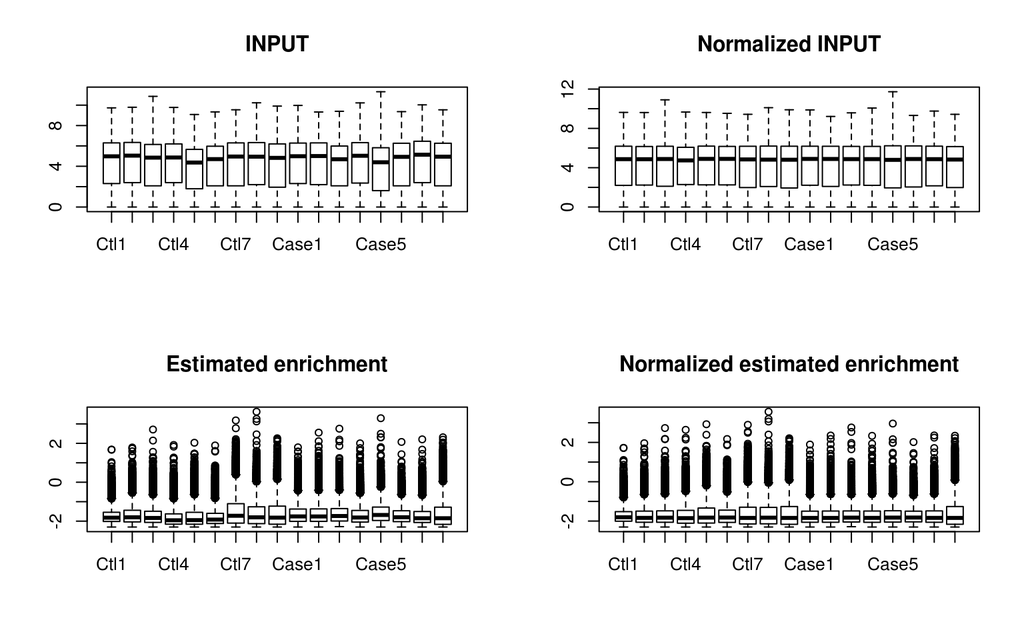

```r
X <- c(rep("Ctl",9),rep("Case",8))
plot.new()
radar <- normalizeLibrary(radar,X)
```

In the returned radar object, there will be normalized gene-level **INPUT** count matrix stored in `radar$geneSum`, which is essentially RNA-seq read count matrix. The normalized *bin-level* read count matrix will be `radar$norm.input`, `radar$norm.ip` respectively. The `radar` object will also contain size factor `radar$sizeFactor` used to normalize each library.

```r
radar$sizeFactor
```

```
##           input        ip
## Ctl1  1.1173142 0.9557192
## Ctl2  1.2005070 1.0987776
## Ctl3  0.9630602 0.9789089
## Ctl4  1.1268572 0.7251289
## Ctl5  0.5860861 0.6959156
## Ctl6  0.8233869 0.7518478
## Ctl7  1.1210298 1.3299486
## Ctl8  1.1344830 1.0665970
## Ctl9  1.0150349 1.0511545
## Case1 1.1000170 1.2295769
## Case2 1.1230659 1.2242543
## Case3 0.8334984 1.2486354
## Case4 1.1711130 1.0683905
## Case5 0.6642079 1.3967383
## Case6 1.0449157 1.0572901
## Case7 1.3100443 0.9620923
## Case8 1.1224454 0.9707009
```

The grouping of the samples can be viewed by:

```r
radar$X
```

```
##  [1] "Ctl"  "Ctl"  "Ctl"  "Ctl"  "Ctl"  "Ctl"  "Ctl"  "Ctl"  "Ctl"  "Case"
## [11] "Case" "Case" "Case" "Case" "Case" "Case" "Case"
```

Next, we can use the *geneSum* of **INPUT** to adjust for the variation of expression level of the **IP** read count. This step aims to account for the variation of **IP** read count attributed to variation of **gene expression level**.

```r
radar <- adjustExprLevel(radar)
```

This step add a new data `radar$ip_adjExpr` to the `radar` object. This matrix data are bin-level read count of **IP** adjusted for gene expression level variation. Then we will need to filter out bins of very low read count because under sampled locus can be strongly affected by technical variation.

```r
radar <- filterBins(radar,minCountsCutOff = 15)
```

```
## Bins with average counts lower than  15  in both groups have been removed...
## Filtering bins that is enriched in IP experiment....
```

### e). Run Poisson Gamma Test

Now we have the count matrix for testing differential methylation ready.  
To run the default PoissonGamma test, we can call the `diiIP()` function:

```r
radar <- diffIP(radar)
```

The code above run test on the effect of variable X defining the experimental group of samples, which is fine if the study is well designed and all known covariates are balanced. However, in most cases, samples might have been processed in more than one batches (especially when sample size is large) where batch effect and other covariate could contributed to the variation.

### f). PCA analysis

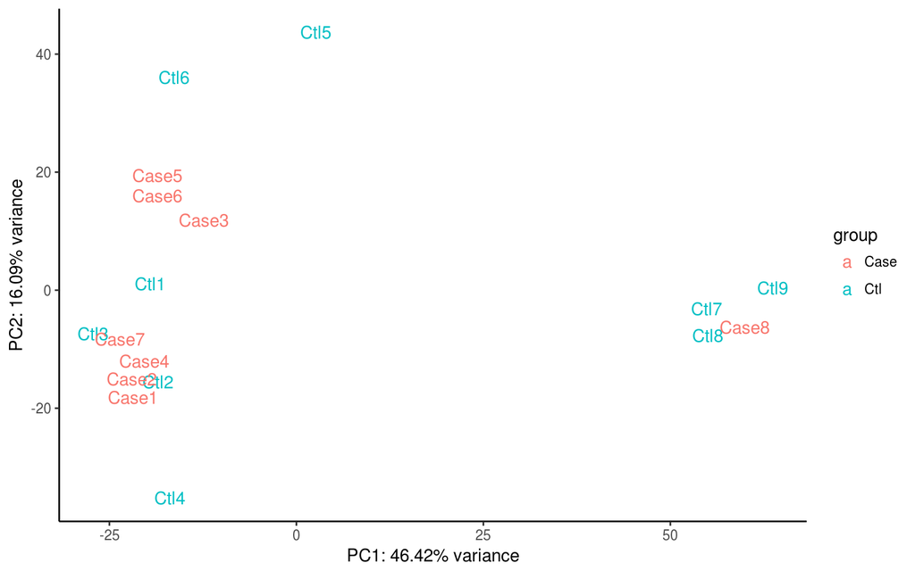

```r
top_bins <- radar$ip_adjExpr_filtered[order(rowMeans(radar$ip_adjExpr_filtered))[1:5000],]
plotPCAfromMatrix(top_bins,group = radar$X)
```

We can see that our Case and Control are not separated by the first two PCs. To check if the samples are separated by batches, we can label the samples by batch instead of by experimental group `X`.

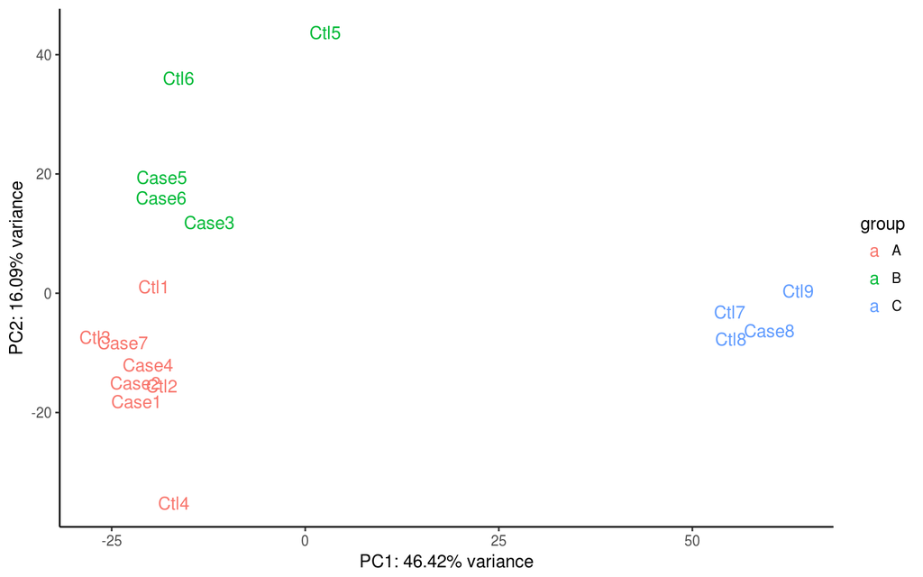

```r
batch <- c("A","A","A","A","B","B","C","C","C","A","A","B","A","B","B","A","C")
plotPCAfromMatrix(top_bins,group = batch)
```

We can see that the samples are clearly separated by batches and we need to account for batch effect in the test. To incorporate **covariates** in study design, we need first define a covariate matrix table where categorical variable should be converted to (0,1) binary variable.

```r
library(rafalib)
X2 <- as.fumeric(c("A","A","A","A","B","B","A","A","A","A","A","B","A","B","B","A","A"))-1 # batch as covariates
X3 <- as.fumeric(c("A","A","A","A","A","A","C","C","C","A","A","A","A","A","A","A","C"))-1 # batch as covariates
X4 <- as.fumeric(c("M","M","F","M","M","M","F","M","M","M","M","F","M","M","M","M","F"))-1 # sex as covariates
cov <- cbind(X2,X3,X4)

cov
```

```
##       X2 X3 X4
##  [1,]  0  0  0
##  [2,]  0  0  0
##  [3,]  0  0  1
##  [4,]  0  0  0
##  [5,]  1  0  0
##  [6,]  1  0  0
##  [7,]  0  1  1
##  [8,]  0  1  0
##  [9,]  0  1  0
## [10,]  0  0  0
## [11,]  0  0  0
## [12,]  1  0  1
## [13,]  0  0  0
## [14,]  1  0  0
## [15,]  1  0  0
## [16,]  0  0  0
## [17,]  0  1  1
```

Run the Poisson Gamma test with covariates to account for know source of variation.

```r
radar <- diffIP(radar,Covariates = cov)
```

or multithread mode

[output not shown]

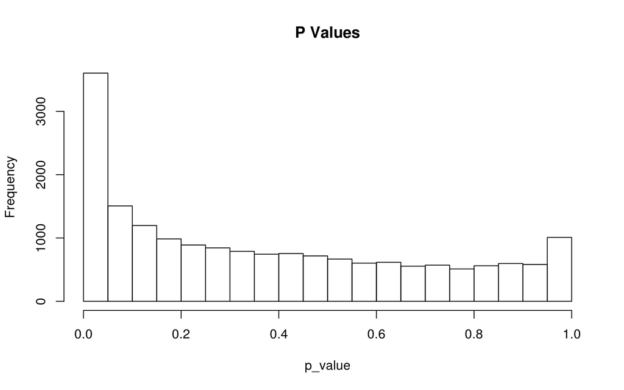

At the end of test, a histgram of p-value distribution will be plotted. The plot can be turned off by `diffIP(radar,Covariates = cov,plotPvalue = FALSE)`.

If for some reasons you want to remove a few samples from the test, you can set index number of the samples you want to skip to exclude them in the Poisson Gamma test.

```
diffIP(radar,Covariates = cov,exclude = c())
```

In the `radar` object returned by the `diffIP()`, a mtrix of test estimators has been stored at `radar$all.est`.

User can check the overall distribution of beta by

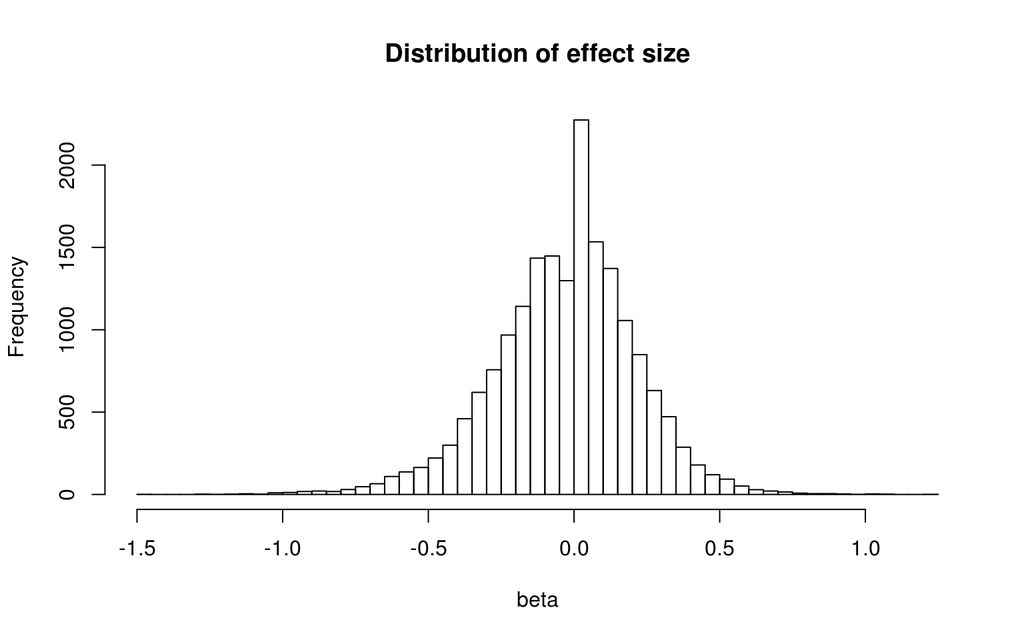

```r
hist(radar$all.est[,"beta1"],breaks = 50,main = "Distribution of effect size",xlab = "beta")
```

```r
## In case of test without covariates, substitute "beta1" by "beta".
```

### g). Visualize the result by heatmap

To assess the pattern of variation of the MeRIP-seq data, we can plot the heatmap of normalized **IP** read counts adjusted for expression level.  
The belowing code shows how to plot heatmap on the radar object.

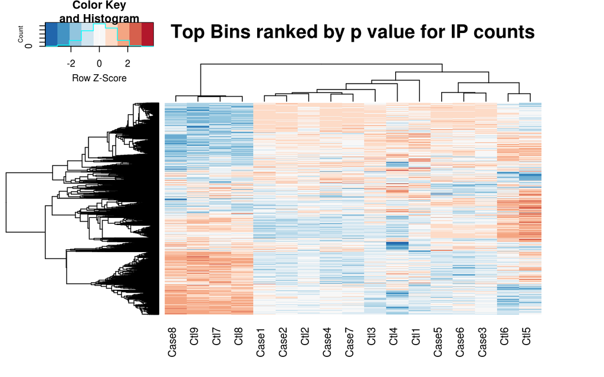

```r
plotHeatMap(radar)
```

In our example, as we determined earlier by PCA plot that batch effect is contibuting substantially to the variation of our data set. we need to plot heatmap on data regressing out covariates as determined earlier in the analysis. To do so, add covariates matrix to the `plotHeatMap()` function.

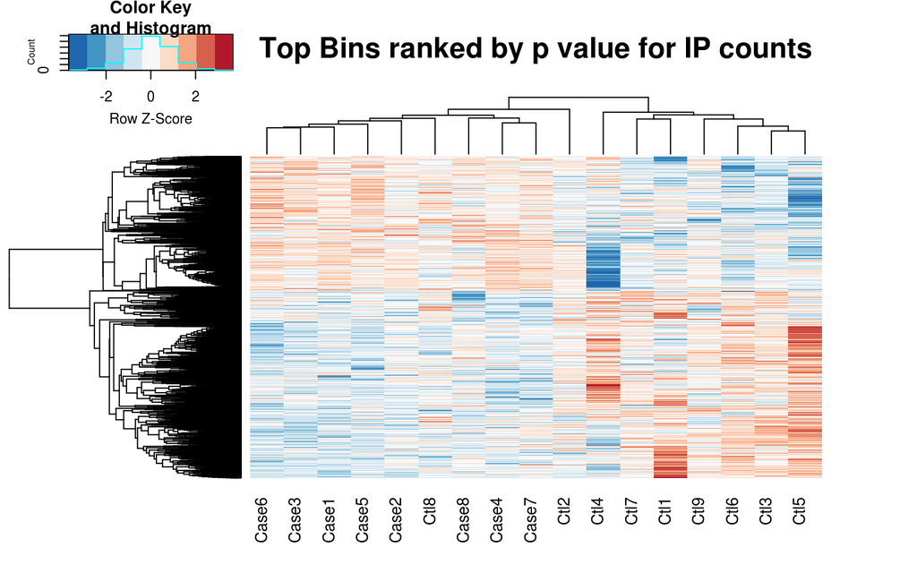

```r
plotHeatMap(radar,covariates = cov)
```

Since plotting too many bins willl look very messy, the function takes the top 5000 bins ranked by test p value. In another words, the heatmap generated here is a visualization the top differential methylated loci. From the heatmap we can see the methylation profile of `Ctl8` looks much closer to Cases than to Controls, which suggest this sample is an outlier.  
At this point, one can proceed to the next step to report the significantly differentially methylated bins to genomic location or repeat the analysis excluding the outlier sample.

### h). Report the result

The count matrix we worked on above are on continuous bins on the transcript and the test was performed on each bin. To report the final result, we want to merge neighbouring bins that pass a significance cutoff because signals for neighbouring bins are assumed to come from the same locus. We merge the p-value of connecting bins by [fisher’s method](https://en.wikipedia.org/wiki/Fisher%27s_method) and report the max beta from neighbouring bins. Besides, We also need to report the genomic location instead of on mRNA location of the bin that passed the cutoff. To do so, call the function:

```r
Diff_peak <- reportPoissonGammaMerge(radar,cutoff = 0.05)
```

```
## Getting significant bins....
## Reporting  329  bins in  240  genes...
## Reporting  302  peaks...
## Hyper-thread registered: TRUE
## Using 6 thread(s) to report merged report...
## Time used to report peaks: 0.264055152734121 mins...
```

The peak is reported at bed12 format with addition column for beta and p value.

```r
head(Diff_peak)
```

```
##              chr     start       end     name score strand thickStart
## 1207        chr1 108200159 108200208 SLC25A24     0      -  108200159
## 1204        chr1  26863920  26863969      SFN     0      +   26863920
## PLCH2,4771  chr1   2502677   2502826    PLCH2     0      +    2502677
## OPN3,2408   chr1 241640102 241640200     OPN3     0      -  241640102
## CASZ1,2463  chr1  10639044  10639142    CASZ1     0      -   10639044
## B3GALT6,474 chr1   1232648   1232747  B3GALT6     0      +    1232648
##              thickEnd itemRgb blockCount blockSizes blockStarts     logFC
## 1207        108200208       0          1         50           0 -1.477604
## 1204         26863969       0          1         50           0  1.237007
## PLCH2,4771    2502826       0          1        150           0 -1.207065
## OPN3,2408   241640200       0          1         99           0 -1.186752
## CASZ1,2463   10639142       0          1         99           0 -1.183458
## B3GALT6,474   1232747       0          1        100           0 -1.143117
##                  p_value
## 1207        3.475624e-07
## 1204        8.612961e-04
## PLCH2,4771  5.229315e-14
## OPN3,2408   2.418924e-08
## CASZ1,2463  6.896925e-06
## B3GALT6,474 5.358113e-07
```

### i). Visualize MeRIP-seq data by sequencing coverage plot.

One of the most straight forward visualization of MeRIP-seq data is the coverage plot. We implemented function to take a `radar` object and plot the mean/median coverage of IP and INPUT for two inferential groups. Here we demonstrate the function using a differential methylated gene reported in above sections.  
To use the plot function, we need to prepare an GTF annotation in GRanges format. This can be done by `GTF <- rtracklayer::import("path/to/gtf")`. This step only need to be done once in each R session.

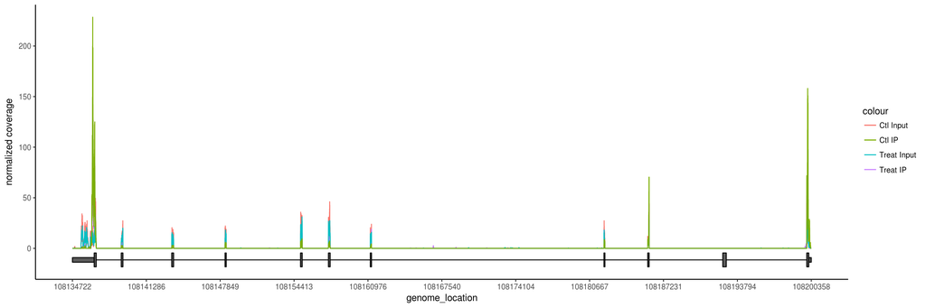

```r
GTF <- rtracklayer::import("~/Database/genome/hg38/hg38_UCSC.gtf")
plotGeneRADAR(radar,geneName = "SLC25A24", center = median, libraryType = "opposite",GTF = GTF)
```

**Note** The groupp label *Treat* and *Ctl* is automatically determined by the group vector `X` defined ealier (you can check by `radar$X`). The first factor in `X` is taken as *Ctl* and another group factor will be taken as *Treat*.  
**Note** The parameter `center = median` define the coverage to be group median. You can also set it to be `center = mean`.

In some cases, the gene has very long introns that the exon regions becomes too narrow to see in the whole gene plot. We can call the same function with additional parameter `ZoomIn` to define a range in the gene to plot (Note `ZoomIn` range need to be within the gene).

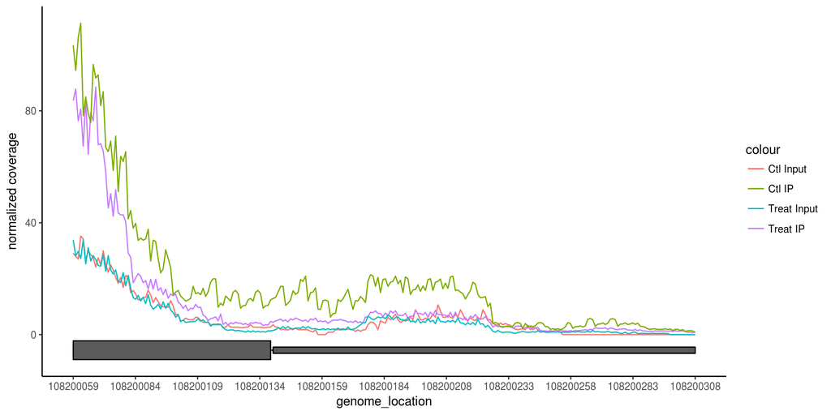

```r
plotGeneRADAR(radar,geneName = "SLC25A24", center = median, libraryType = "opposite",GTF = GTF,ZoomIn = c(108200059,108200308 ) )
```

From the coverage plot we can see the in the “Treat” group, the m6A peak is significantly decreased.

## 4. Model

### a). Poisson model

$$\begin{eqnarray*}
Y_{i} &\sim& Poi(\lambda_{i}) \\
\log(\lambda_{i} ) & = & \mu_1 + X_i \beta +e_{i}
\end{eqnarray*}$$
We assume random effect $e_{i} \in \log\text{Gamma}(\psi, \psi)$, with scale parameter $\psi$ and mean equal to $1$. This is equivalent to $\lambda_{i} = e^{ \mu_1 + X_i \beta} w_i$ where $w_i \in \text{Gamma}(\psi, \psi)$ .
$$\begin{eqnarray*}
P( Y_i | \Theta, - w_i) &=& \int e^{-w_i e^{ \mu_1 + X_i \beta}} \frac{(w_i e^{ \mu_1 + X_i \beta} )^{Y_i}}{Y_i!} \frac{\psi^\psi w_i^{\psi-1}e^{-\psi w_i}}{\Gamma(\psi)} d w_i\\
&=& \frac{ \psi^\psi }{Y_i! } \frac{ \Gamma(Y_i+\psi) } {\Gamma(\psi) } \frac{ (e^{ \mu_1 + X_i \beta})^{Y_i}}{ (e^{ \mu_1 + X_i \beta} + \psi)^{Y_i + \psi}}
\end{eqnarray*}$$
The marginal log likelihood of observing $\mathbf{Y}$ can be written as:
$$\begin{eqnarray*}
\log L( \mathbf{Y} ) &=& \sum_{i}^n [ Y_i( \mu_1 + X_i \beta) + \psi \log \psi + \log \Gamma(Y_i + \psi) - \log Y_i! - \log \Gamma( \psi) - (Y_i + \psi) \log( e^{ \mu_1 + X_i \beta} + \psi)] \\
\end{eqnarray*}$$

### b). Estimation

We use gradient ascent algorithm to estimate the parameters, which involves the calculation of first derivatives.
$$\begin{eqnarray*}
\frac{ \partial \log L( \mathbf{Y} ) }{ \partial \beta } &=& \sum_{i}^n \ \Big[ Y_i - \big (Y_i + \psi \big )\frac{e^{ \mu_1+ X_i \beta}}{ e^{ \mu_1 + X_i \beta} +\psi} \Big] X_i \\
\frac{ \partial \log L( \mathbf{Y} ) }{ \partial \psi} &=& \sum_{i}^n \Big [ \log \psi + 1 - \frac{Y_i + \psi }{ e^{ \mu_1 + X_i \beta} +\psi} - \log ( e^{ \mu_1 + X_i \beta} +\psi ) \\
&&+ \text{digamma} ( Y_i + \psi) - \text{digamma} ( \psi) \Big ] \\
\frac{ \partial \log L( \mathbf{Y} ) }{ \partial \mu _1} &=& \sum_{i}^n \Big[ Y_i - \big (Y_i + \psi \big ) \frac{e^{ \mu_1 + X_i \beta} }{e^{ \mu_1 + X_i \beta} + \psi} \Big]
\end{eqnarray*}$$

### c). Inference

We use log-likelihood ratio test to make the inference, where the null model is
$$\begin{eqnarray*}
Y_{i} &\sim& Poi(\lambda_{i}) \\
\log(\lambda_{i} ) & = & \mu_1 + e_{i}.
\end{eqnarray*}$$

### d). Poisson model + covariates

$$\begin{eqnarray*}
Y_{i} &\sim& Poi(\lambda_{i}) \\
\log(\lambda_{i} ) & = & \mu_1 + \mathbf{X_i} \mathbf{\beta} +e_{i}
\end{eqnarray*}$$

We assume random effect $e_{i} \in \log\text{Gamma}(\psi, \psi)$, with scale parameter $\psi$ and mean equal to $1$. This is equivalent to $\lambda_{i} = e^{ \mu_1 + \mathbf{X_i} \mathbf{\beta}} w_i$ where $w_i \in \text{Gamma}(\psi, \psi)$ .

$$\begin{eqnarray*}
P( Y_i | \Theta, - w_i) &=& \int e^{-w_i e^{ \mu_1 + \mathbf{X_i} \mathbf{\beta}}} \frac{(w_i e^{ \mu_1 + \mathbf{X_i} \mathbf{\beta}} )^{Y_i}}{Y_i!} \frac{\psi^\psi w_i^{\psi-1}e^{-\psi w_i}}{\Gamma(\psi)} d w_i\\
&=& \frac{ \psi^\psi }{Y_i! } \frac{ \Gamma(Y_i+\psi) } {\Gamma(\psi) } \frac{ (e^{ \mu_1 + \mathbf{X_i} \mathbf{\beta}})^{Y_i}}{ (e^{ \mu_1 + \mathbf{X_i} \mathbf{\beta}} + \psi)^{Y_i + \psi}}
\end{eqnarray*}$$
The marginal log likelihood of observing $\mathbf{Y}$ can be written as:
$$\begin{eqnarray*}
\log L( \mathbf{Y} ) &=& \sum_{i}^n [ Y_i( \mu_1 + \mathbf{X_i} \mathbf{\beta} ) + \psi \log \psi + \log \Gamma(Y_i + \psi) - \log Y_i! - \log \Gamma( \psi) - (Y_i + \psi) \log( e^{ \mu_1 + \mathbf{X_i} \mathbf{\beta}} + \psi)] \\
\end{eqnarray*}$$

#### Estimation

We use gradient ascent algorithm to estimate the parameters, which involves the calculation of first derivatives.
$$\begin{eqnarray*}
\frac{ \partial \log L( \mathbf{Y} ) }{ \partial \beta_k } &=& \sum_{i}^n \ \Big[ Y_i - \big (Y_i + \psi \big )\frac{e^{ \mu_1+ \mathbf{X_i} \mathbf{\beta}}}{ e^{ \mu_1 + \mathbf{X_i} \mathbf{\beta}} +\psi} \Big] X_{ik} \\
\frac{ \partial \log L( \mathbf{Y} ) }{ \partial \psi} &=& \sum_{i}^n \Big [ \log \psi + 1 - \frac{Y_i + \psi }{ e^{ \mu_1 + \mathbf{X_i} \mathbf{\beta} } +\psi} - \log ( e^{ \mu_1 + \mathbf{X_i} \mathbf{\beta}} +\psi ) \\
&&+ \text{digamma} ( Y_i + \psi) - \text{digamma} ( \psi) \Big ] \\
\frac{ \partial \log L( \mathbf{Y} ) }{ \partial \mu _1} &=& \sum_{i}^n \Big[ Y_i - \big (Y_i + \psi \big ) \frac{e^{ \mu_1 + \mathbf{X_i} \mathbf{\beta}} }{e^{ \mu_1 + \mathbf{X_i} \mathbf{\beta}} + \psi} \Big]
\end{eqnarray*}$$

#### Inference

We use log-likelihood ratio test to make the inference for each $\beta_k$, where the null model is
$$\begin{eqnarray*}
Y_{i} &\sim& Poi(\lambda_{i}) \\
\log(\lambda_{i} ) & = & \mu_1 + \sum_{j \neq k}^{K} X_{ij} \beta_j + e_{i}.
\end{eqnarray*}$$
We use observed fisher information to make the inference for all parameters. The calculation involves all second derivatives and partial derivatives.
$$\begin{eqnarray*}
\frac{ \partial^2\log L( \mathbf{Y} )}{\partial \beta_k^2} &=& - \sum_{i}^n \frac{e^{ \mu_1 + \mathbf{X_i} \mathbf{\beta} }}{ \big ( e^{ \mu_1 + \mathbf{X_i} \mathbf{\beta} } + \psi \big ) ^2} \psi \big (Y_i + \psi \big ) X_{ik}^2 \\
\frac{ \partial^2\log L( \mathbf{Y} )}{\partial \beta_k \beta_k'} &=& - \sum_{i}^n \frac{e^{ \mu_1 + \mathbf{X_i} \mathbf{\beta} }}{ \big ( e^{ \mu_1 + \mathbf{X_i} \mathbf{\beta} } + \psi \big ) ^2} \psi \big (Y_i + \psi \big ) X_{ik} X_{ik'} \\
\frac{ \partial^2 \log L( \mathbf{Y} ) }{\partial \beta_k \partial \mu_1} &=& - \sum_{i}^n \frac{e^{ \mu_1 + \mathbf{X_i} \mathbf{\beta} }}{ \big ( e^{ \mu_1 + \mathbf{X_i} \mathbf{\beta} } + \psi \big ) ^2} \psi \big (Y_i + \psi \big ) X_{ik} \\
\frac{ \partial^2 \log L( \mathbf{Y} ) }{\partial \beta_k \partial \psi} &=& \sum_{i}^n \Big[ \frac{e^{ \mu_1 + \mathbf{X_i} \mathbf{\beta} } }{ \big ( e^{ \mu_1 + \mathbf{X_i} \mathbf{\beta} } + \psi \big ) ^2} \big (Y_i + \psi \big ) X_{ik} - \frac{e^{ \mu_1 + \mathbf{X_i} \mathbf{\beta} } }{ e^{ \mu_1 + \mathbf{X_i} \mathbf{\beta} } + \psi } X_{ik} \Big]\\
\frac{ \partial^2 \log L( \mathbf{Y} ) }{\partial \mu_1^2} &=& - \sum_{i}^n \frac{e^{ \mu_1 + \mathbf{X_i} \mathbf{\beta}} }{ \big ( e^{ \mu_1 + \mathbf{X_i} \mathbf{\beta} } + \psi \big ) ^2} \psi \big (Y_i + \psi \big ) \\
\frac{ \partial^2 \log L( \mathbf{Y} ) }{\partial \mu_1 \partial \psi} &=& \sum_{i}^n \Big[ \frac{e^{ \mu_1 + \mathbf{X_i} \mathbf{\beta} } }{ \big ( e^{ \mu_1 + \mathbf{X_i} \mathbf{\beta} } + \psi \big ) ^2} \big (Y_i + \psi \big ) -\frac{e^{ \mu_1 + \mathbf{X_i} \mathbf{\beta} } }{ e^{ \mu_1 + \mathbf{X_i} \mathbf{\beta} } + \psi } \Big] \\
\frac{ \partial^2 \log L( \mathbf{Y} ) }{\partial \psi^2} &=& \sum_{i}^n \Big[ \frac{1}{\psi} - \frac{2}{e^{ \mu_1 + \mathbf{X_i} \mathbf{\beta} } + \psi} + \frac{Y_i + \psi }{ \big ( e^{ \mu_1 + \mathbf{X_i} \mathbf{\beta}} + \psi \big ) ^2} + \text{trigamma}(Y_i + \psi) - \text{trigamma}(\psi) \Big] \\
\end{eqnarray*}$$

## Acknowledgments

We have benefited in the development of RADAR from the help and feedback of many individuals, including but not limited to:

## References

[1] Love, M. I.; Huber, W.; & Anders, S. Moderated estimation of fold change and dispersion for RNA-seq data with DESeq2. Genome Biology. 2014 15(12), 550.